# PS2 R Solutions

Matthew Alampay Davis

October 11, 2021

# Question 1

First, let’s replicate the table

| country | cigarettes | deaths |
| --- | --- | --- |
| Switzerland | 530 | 250 |
| Finland | 1115 | 350 |
| Great Britain | 1145 | 465 |
| Canada | 510 | 150 |
| Denmark | 380 | 165 |

## 1i)

```r
mean(cancer$cigarettes)
```

```
[1] 736
```

The sample mean for the number of cigarettes consumed per capita in 1930 is 736

```r
mean(cancer$deaths)
```

```
[1] 276
```

The sample mean for the number of lung cancer deaths per million people in 1950 is 276

## 1ii)

```r
sd(cancer$cigarettes)
```

```
[1] 364.4071
```

The sample standard deviation for the number of cigarettes consumed per capita in 1930 is 364

```r
sd(cancer$deaths)
```

```
[1] 132.3537
```

The sample standard deviation for the number of lung cancer deaths per million people in 1950 is 132

## 1iii)

```r
cor(cancer$cigarettes, cancer$deaths)
```

```
[1] 0.9262529
```

The sample correlation between the two variables is 0.926

## 1iv)

```r
summary(cancer.model)
```

```
Call:
lm_robust(formula = deaths ~ cigarettes, data = cancer, se_type = "stata")

Standard error type:  HC1

Coefficients:
            Estimate Std. Error t value Pr(>|t|)  CI Lower CI Upper DF
(Intercept)  28.3966    54.6853  0.5193  0.63945 -145.6365 202.4296  3
cigarettes    0.3364     0.0795  4.2314  0.02415    0.0834   0.5894  3

Multiple R-squared:  0.8579 ,   Adjusted R-squared:  0.8106
F-statistic:  17.9 on 1 and 3 DF,  p-value: 0.02415
```

The estimated $\hat{\beta}_1$ is 0.336

## 1v)

From the same output, we can see that the estimated$\hat{\beta}_0$ is 28.4

## 1vi)

```r
cancer$predictions
```

```
[1] 206.6979 403.5023 413.5948 199.9696 156.2353
```

## 1vii)

```r
cancer$residuals
```

```
[1]  43.302050 -53.502316  51.405153 -49.969595   8.764708
```

One thing to note here is that lm_robust models don’t allow you to directly pull residuals. Instead, we just create them as the difference between the true values and the fitted/predicted values. Alternatively, we could create a non-robust lm model object and use the $ symbol to pull them:

```r
cancer.model.nonrobust$residuals
```

```
         1          2          3          4          5
 43.302050 -53.502316  51.405153 -49.969595   8.764708
```

They are exactly the same since residuals are invariant to the type of standard error used

# Question 2

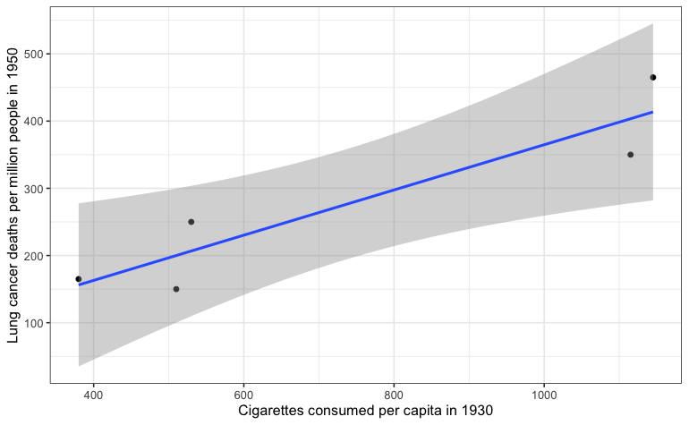

```r
cancer.plot
```

The estimated intercept is 28.4, which suggests that the linear model would predict that a country that consumes zero cigarettes in 1930 would have 28.4 lung cancer deaths per million people in 1950.

The slope of the regression is 0.336, which suggests that an increase by one cigarette concsumed per capita in 1930 is associated with an increase in the death rate of 0.336 lung cancer deaths per million in 1950.

# Question 3

## 3(a)

|  | wage | hours | IQ | KWW | educ | exper | tenure | age | married | black | south | urban | sibs | brthord | meduc | feduc | lwage |
| --- | --- | --- | --- | --- | --- | --- | --- | --- | --- | --- | --- | --- | --- | --- | --- | --- | --- |
| 1 | 769 | 40 | 93 | 35 | 12 | 11 | 2 | 31 | 1 | 0 | 0 | 1 | 1 | 2 | 8 | 8 | 6.645091 |
| 2 | 808 | 50 | 119 | 41 | 18 | 11 | 16 | 37 | 1 | 0 | 0 | 1 | 1 | NA | 14 | 14 | 6.694562 |
| 3 | 825 | 40 | 108 | 46 | 14 | 11 | 9 | 33 | 1 | 0 | 0 | 1 | 1 | 2 | 14 | 14 | 6.715384 |
| 4 | 650 | 40 | 96 | 32 | 12 | 13 | 7 | 32 | 1 | 0 | 0 | 1 | 4 | 3 | 12 | 12 | 6.476973 |
| 5 | 562 | 40 | 74 | 27 | 11 | 14 | 5 | 34 | 1 | 0 | 0 | 1 | 10 | 6 | 6 | 11 | 6.331502 |
| 6 | 1400 | 40 | 116 | 43 | 16 | 14 | 2 | 35 | 1 | 1 | 0 | 1 | 1 | 2 | 8 | NA | 7.244227 |

The mean value of wage is 957.95 units, its SD = 404.36, with min value of 115 and max value of 3078. Do the same for the other model variables.

## 3(b)

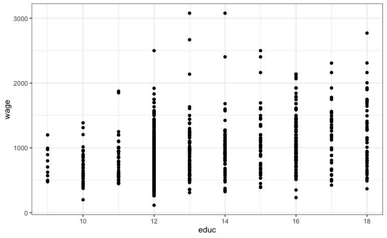

It looks like that as the number of years of education increases, wage tends to increase. It seems that they are possitively correlated, though it is not clear.

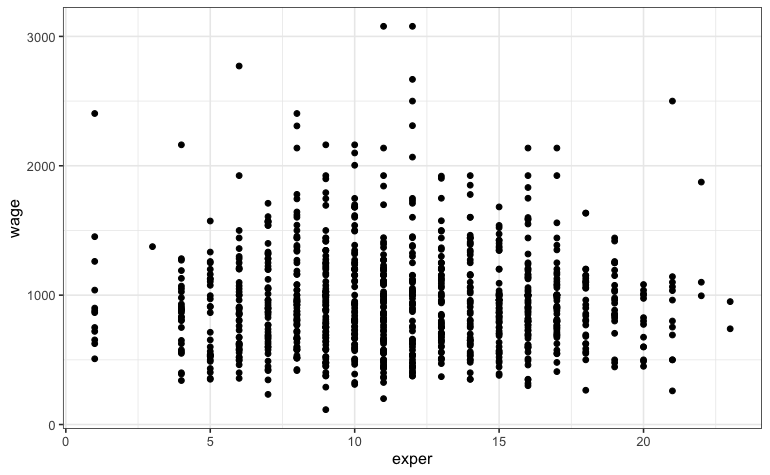

It looks like that as the number of years of experience increases, wages tend to increase first then start to decrease after a certain threshold level of years of experience. It seems that they are not linearly correlated.

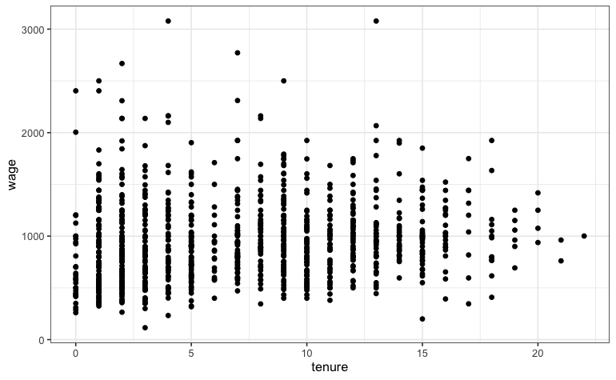

There seems to be no meaningful or clear positive or negative relationship between these two variables by visual inspection of this plot. It seems that they may have a slightly positive correlation.

## 3(c)

```r
summary(wage.model1)
```

```
Call:
lm_robust(formula = wage ~ educ, data = wage, se_type = "stata")

Standard error type:  HC1

Coefficients:
            Estimate Std. Error t value  Pr(>|t|) CI Lower CI Upper  DF
(Intercept)   146.95     80.270   1.831 6.746e-02   -10.58    304.5 933
educ           60.21      6.157   9.780 1.432e-21    48.13     72.3 933

Multiple R-squared:  0.107 ,    Adjusted R-squared:  0.106
F-statistic: 95.65 on 1 and 933 DF,  p-value: < 2.2e-16
```

Matt: note that our $t$ statistic is smaller and our confidence interval is wider than appears in the ‘official’ Stata solutions, which did not include robust standard errors. They’d be identical if it had.

```r
summary(wage.model2)
```

```
Call:
lm_robust(formula = wage ~ exper, data = wage, se_type = "stata")

Standard error type:  HC1

Coefficients:
            Estimate Std. Error  t value   Pr(>|t|) CI Lower CI Upper  DF
(Intercept) 955.6049     37.043 25.79716 3.351e-111  882.908 1028.302 933
exper         0.2024      2.881  0.07026  9.440e-01   -5.451    5.856 933

Multiple R-squared:  4.795e-06 ,    Adjusted R-squared:  -0.001067
F-statistic: 0.004936 on 1 and 933 DF,  p-value: 0.944
```

```r
summary(wage.model3)
```

```
Call:
lm_robust(formula = wage ~ tenure, data = wage, se_type = "stata")

Standard error type:  HC1

Coefficients:
            Estimate Std. Error t value   Pr(>|t|) CI Lower CI Upper  DF
(Intercept)   884.02     24.446  36.162 1.071e-179  836.040   931.99 933
tenure         10.22      2.507   4.076  4.963e-05    5.299    15.14 933

Multiple R-squared:  0.01645 ,  Adjusted R-squared:  0.0154
F-statistic: 16.62 on 1 and 933 DF,  p-value: 4.963e-05
```

## 3(d)

```r
confint(wage.model1, level = 0.99)
```

```
                0.5 %    99.5 %
(Intercept) -60.23198 354.13686
educ         44.32251  76.10606
```